# STAT 331 Portfolio

## Reproducibility

**R-1: I can create professional looking, reproducible analyses using RStudio projects, Quarto documents, and the here package.**

I’ve done this in the following provided assignments: Lab 3, Challenge 3

**R-2: I can write well documented and tidy code.**

- Example 1

```r
# Challenge 4
home_prices_clean <- home_prices |>
  # selecting only 2015 - 2018 because those are the years in avocado dataset
  select("RegionName" | "2015-01-31":"2018-12-31") |>
  pivot_longer(cols = "2015-01-31":"2018-12-31", names_to = "Date",
               values_to = "Typical home value") |>
  group_by(RegionName) |>
  summarize(`Average typical home value` = mean(`Typical home value`))
```

- Example 2

```r
# Challenge 3
hiphop_clean <- hiphop |>
    replace(is.na(hiphop), 0) |>
    mutate(
      word = as.factor(word),
      subj = as.factor(subj),
      sex = as.factor(sex),
      ethnic = as.factor(ethnic),
      familiarity = as.factor(familiarity),
      across(jayz:bieber, as.factor)
    )
```

**R-3: I can write robust programs that are resistant to changes in inputs.**

- Example 1

```r
# Lab 4 Q4
avocados_clean |>
  separate(col = Date, into = c("Year", "Month", "Day"), sep = "-") |>
  group_by(Month) |>
  summarize(total = sum(`Total Volume`)) |>
  slice_max(order_by = total)
```

- Example 2

```r
# Lab 3 Q14
hiphop_clean |>
  filter(ethnic == "white" &
           sex == "Male" &
           age > 16 &
           age < 24 &
           city > 10000 &
           city < 60000) |>
  slice_max(bieber) |>
  distinct(subj)
```

## Data Visualization & Summarization

**DVS-1: I can create visualizations for a *variety* of variable types (e.g., numeric, character, factor, date)**

- numeric variables

```r
# Lab 2 Q6
ggplot(data = surveys, mapping = aes(x = weight, y = hindfoot_length)) +
  geom_jitter(alpha = 0.3)
```

- numeric variables and categorical variables

```r
# Lab 4 Q6
avocados_cali |>
  group_by(region, type) |>
  summarize(avg_price = mean(AveragePrice)) |>
  ggplot(mapping = aes(x = region, y = avg_price)) +
  geom_line(aes(group = region)) +
  geom_point(aes(color = type)) +
  labs(x = "California region", y = "Average avocado price")
```

- categorical variables

```r
# Lab 5 Part 3 Q7
surveys |>
  drop_na(day_of_week) |>
  ggplot(mapping = aes(x = fct_relevel(day_of_week,
                                       c("Mon", "Tue", "Wed", "Thu", "Fri", "Sat", "Sun")))) +
  geom_bar() +
  labs(x = "Day of week", y = NULL, title = "Number of rodents captured")
```

- dates

```r
# Lab 5 Part 2
surveys |>
  group_by(genus, year) |>
  summarize(avg_weight = mean(weight)) |>
  ggplot(mapping = aes(x = year, y = avg_weight, color = fct_reorder(genus, avg_weight))) +
  geom_line() +
  labs(x = "Year", y = NULL,
       title = "Average weight of rodents over time by genus (g)",
       color = "Genus")
```

**DVS-2: I use plot modifications to make my visualization clear to the reader.**

- Example 1

```r
# Lab 4 Q6
avocados_cali |>
  group_by(region, type) |>
  summarize(avg_price = mean(AveragePrice)) |>
  ggplot(mapping = aes(x = region, y = avg_price)) +
  geom_line(aes(group = region)) +
  geom_point(aes(color = type)) +
  labs(x = "California region", y = "Average avocado price")
```

- Example 2

```r
# Lab 5 Q2
ggplot(data = surveys, mapping = aes(x = weight, y = fct_reorder(species, weight))) +
  geom_jitter(color = "cadetblue", alpha = 0.3) +
  geom_boxplot(outlier.shape = NA) +
  labs(x = "Weight of rodents (g)",
       y = NULL, title = "Distribution of weight of rodents by species")
```

**DVS-3: I show creativity in my visualizations**

- Example 1

```r
# Challenge 2
ggplot(data = surveys, mapping = aes(x = weight, y = species, color = genus)) +
  geom_boxplot(outlier.shape = NA) +
  labs(x = "weight of animal (g)", y = "species of animal", color = "genus of animal") +
  scale_color_manual(values = cartography::carto.pal(pal1 = "multi.pal", n1 = 8))
```

**DVS-4: I can calculate numerical summaries of variables.**

- Example 1

```r
# Lab 4 Q3
avocados_major |>
  filter(type == "organic" & year == 2017) |>
  group_by(region) |>
  summarize(total = sum(`Small Bags`)) |>
  slice_max(order_by = total)
```

- Example 2

```r
# Lab 3 Q12
word_familiarity <- hiphop_clean |>
  filter(eth == "non-white" & sex == "Female") |>
  group_by(word) |>
  summarize(avg_familiarity = mean(
    as.numeric(
      familiarity)))
```

**DVS-5: I can find summaries of variables across multiple groups.**

- Example 1

```r
# Lab 4 Q6
avocados_cali |>
  group_by(region, type) |>
  summarize(avg_price = mean(AveragePrice)) |>
  pivot_wider(names_from = "type", values_from = "avg_price") |>
  mutate(price_diff = abs(conventional - organic))
```

- Example 2

```r
# Lab 4 Q7
avocados_cali |>
  group_by(region, type) |>
  summarize(Small = mean(`Small/Medium Hass Avocado`),
            Large = mean(`Large Hass Avocado`),
            `Extra Large` = mean(`Extra Large Hass Avocado`),
            total = sum(Small, Large, `Extra Large`)) |>
  mutate(across(
    .cols = "Small":"Extra Large", .fns = ~ .x / total)
    ) |>
  pivot_longer(cols = "Small":"Extra Large", names_to = "Avocado Size",
               values_to = "proportion") |>
  mutate(`Avocado Size` = factor(`Avocado Size`,
                                 levels = c("Small", "Large", "Extra Large"))
         ) |>
  ggplot(mapping = aes(x = region, y = proportion, fill = `Avocado Size`)) +
  geom_bar(position = "stack", stat = "identity") +
  facet_wrap(~ type) +
  scale_x_discrete(guide = guide_axis(n.dodge = 2)) +
  labs(x = "Region of CA", y = "Proportion of Mean Avocados Sold")
```

**DVS-6: I can create tables which make my summaries clear to the reader.**

**DVS-7: I show creativity in my tables.**

## Program Efficiency

**PE-1: I can write concise code which does not repeat itself.**

- using a single function call

```r
# Challenge 3
hiphop_clean <- hiphop |>
    replace(is.na(hiphop), 0) |>
    mutate(
      word = as.factor(word),
      subj = as.factor(subj),
      sex = as.factor(sex),
      ethnic = as.factor(ethnic),
      familiarity = as.factor(familiarity),
      across(jayz:bieber, as.factor)
    )
```

- `across()`

```r
# Lab 3 Q5
hiphop_clean <- hiphop |>
    replace(is.na(hiphop), 0) |>
    mutate(
      across(.cols = c(word:sex, ethnic, familiarity, jayz:bieber), .fns = ~ as.factor(.x))
    )
```

**PE-2: I can write functions to reduce repetition in my code.**

- Example 1

```r
# Lab 3 Q14 (revised)
hiphop_clean |>
  filter(ethnic == "white",
           sex == "Male",
           age > 16,
           age < 24,
           city > 10000,
           city < 60000) |>
  slice_max(bieber) |>
  distinct(subj)
```

- Example 2

```r
# Lab 4 Q6
avocados_cali |>
  group_by(region, type) |>
  summarize(avg_price = mean(AveragePrice)) |>
  ggplot(mapping = aes(x = region, y = avg_price)) +
  geom_line(aes(group = region)) +
  geom_point(aes(color = type)) +
  labs(x = "California region", y = "Average avocado price")
```

**PE-3:I can use iteration to reduce repetition in my code.**

- `across()`

```r
# Lab 3 Q5
hiphop_clean <- hiphop |>
    replace(is.na(hiphop), 0) |>
    mutate(
      across(.cols = c(word:sex, ethnic, familiarity, jayz:bieber), .fns = ~ as.factor(.x))
    )
```

**PE-4: I can use modern tools when carrying out my analysis.**

- Example 1

```r
# Lab 4 Q6
avocados_cali |>
  group_by(region, type) |>
  summarize(avg_price = mean(AveragePrice)) |>
  pivot_wider(names_from = "type", values_from = "avg_price") |>
  mutate(price_diff = abs(conventional - organic))
```

- Example 2

```r
# Lab 4 Q7
avocados_cali |>
  group_by(region, type) |>
  summarize(Small = mean(`Small/Medium Hass Avocado`),
            Large = mean(`Large Hass Avocado`),
            `Extra Large` = mean(`Extra Large Hass Avocado`),
            total = sum(Small, Large, `Extra Large`)) |>
  mutate(across(
    .cols = "Small":"Extra Large", .fns = ~ .x / total)
    ) |>
  pivot_longer(cols = "Small":"Extra Large", names_to = "Avocado Size",
               values_to = "proportion") |>
  mutate(`Avocado Size` = factor(`Avocado Size`,
                                 levels = c("Small", "Large", "Extra Large"))
         ) |>
  ggplot(mapping = aes(x = region, y = proportion, fill = `Avocado Size`)) +
  geom_bar(position = "stack", stat = "identity") +
  facet_wrap(~ type) +
  scale_x_discrete(guide = guide_axis(n.dodge = 2)) +
  labs(x = "Region of CA", y = "Proportion of Mean Avocados Sold")
```

## Data Simulation & Modeling

**DSM-1: I can simulate data from a *variety* of probability models.**

**DSM-2: I can fit a linear regression and extract necessary summary measures.**

## Revising My Thinking

I have had to revise each of the lab assignments so far, but I have done my best to revise all of them after taking into account the feedback given. I have also learned a lot from the feedback and try to incorporate them into future assignments. I leave thoughtful comments on what my thought process was previously and how it is changed on my revisions. I’ve also added a couple revisions to code examples in my portfolio; for example, I’ve adjusted some filter functions to use commas instead of &s for multiple filter arguments.

## Extending My Thinking

I believe I have been extending my thinking often because I have had to look up a lot of functions externally in many of the code examples I have provided. I also try to do more research when it is on subjects I’m unfamiliar with; for example, I’ve had to look up major geographical regions and cultural appropriation of AAE. On challenges, I try to do at least the medium difficulty offered.

## Peer Support & Collaboration

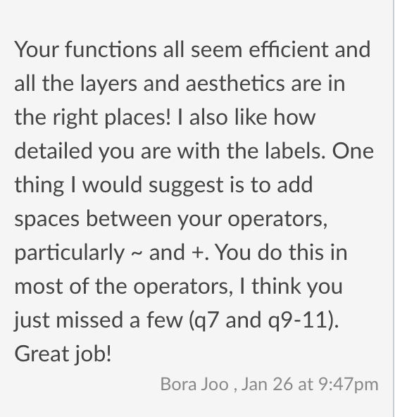